# HollisT_Week9

Tim Hollis

2025-11-09

```r
# Load and inspect data

travel_data <- read.csv('travel_insurance_anova.csv')

# Convert factor variables to maintain proper ANOVA structure

travel_data$Agency.Type <- as.factor(travel_data$Agency.Type)
travel_data$Distribution.Channel <- as.factor(travel_data$Distribution.Channel)

# Examine the structure

cat('Structure of Data:\n')
```

```
## Structure of Data:
```

```r
str(travel_data)
```

```
## 'data.frame':    60765 obs. of  3 variables:
##  $ Agency.Type         : Factor w/ 2 levels "Airlines","Travel Agency": 1 1 1 1 1 1 1 1 1 1 ...
##  $ Distribution.Channel: Factor w/ 2 levels "Offline","Online": 2 2 2 1 2 2 2 2 2 2 ...
##  $ Net.Sales           : num  0.07 0.07 0.07 0.07 0.13 0.19 0.19 0.19 0.19 0.19 ...
```

```r
# Check for missing values

missing_summary <- sapply(travel_data, function(x) sum(is.na(x)))
cat('Missing values in each column:')
```

```
## Missing values in each column:
```

```r
print(missing_summary)
```

```
##          Agency.Type Distribution.Channel            Net.Sales
##                    0                    0                    0
```

```r
# Check the distribution of categorical variables

cat('Distribution of Agency Types:')
```

```
## Distribution of Agency Types:
```

```r
agency_dist <- table(travel_data$Agency.Type)
print(agency_dist)
```

```
##
##      Airlines Travel Agency
##         17072         43693
```

```r
cat('Distribution of Distribution Channels:')
```

```
## Distribution of Distribution Channels:
```

```r
channel_dist <- table(travel_data$Distribution.Channel)
print(channel_dist)
```

```
##
## Offline  Online
##    1078   59687
```

```r
# Check proportions for both factors

cat('Proportions of Agency Types:')
```

```
## Proportions of Agency Types:
```

```r
agency_prop <- prop.table(agency_dist)
agency_prop_formatted <- data.frame(
  Agency_Type = names(agency_prop),
  Count = as.numeric(agency_dist),
  Proportion = paste0(round(agency_prop * 100, 2), '%')
)

cat('Proportions of Distribution Channels:')
```

```
## Proportions of Distribution Channels:
```

```r
channel_prop <- prop.table(channel_dist)
channel_prop_formatted <- data.frame(
  Channel = names(channel_prop),
  Count = as.numeric(channel_dist),
  Proportion = paste0(round(channel_prop * 100, 2), '%')
)

# Display both tables

kable(agency_prop_formatted, caption = 'Agency Type') %>%
  kable_styling(bootstrap_options = c('striped', 'hover', 'condensed'), full_width = FALSE)
```

Agency Type

| Agency_Type | Count | Proportion |
| --- | --- | --- |
| Airlines | 17072 | 28.1% |
| Travel Agency | 43693 | 71.9% |

```r
kable(channel_prop_formatted, caption = 'Distribution Channel') %>%
  kable_styling(bootstrap_options = c('striped', 'hover', 'condensed'), full_width = FALSE)
```

Distribution Channel

| Channel | Count | Proportion |
| --- | --- | --- |
| Offline | 1078 | 1.77% |
| Online | 59687 | 98.23% |

```r
# Create a cross-tabulation

cross_tab <- table(travel_data$Agency.Type, travel_data$Distribution.Channel)
cat('Cross-tabulation of Agency Type vs Distribution Channel:')
```

```
## Cross-tabulation of Agency Type vs Distribution Channel:
```

```r
print(cross_tab)
```

```
##
##                 Offline Online
##   Airlines           13  17059
##   Travel Agency    1065  42628
```

```r
# Summary statistics by groups (all four possible combinations)

group_summary <- travel_data %>%
  group_by(Agency.Type, Distribution.Channel) %>%
  summarise(
    Count = n(),
    Mean_Net_Sales = mean(Net.Sales),
    SD_Net_Sales = sd(Net.Sales),
    Min_Net_Sales = min(Net.Sales),
    Max_Net_Sales = max(Net.Sales),
    .groups = 'drop'
  )

cat('Summary Statistics by Group:')
```

```
## Summary Statistics by Group:
```

```r
group_summary %>%
  mutate(across(c(Mean_Net_Sales, SD_Net_Sales, Min_Net_Sales, Max_Net_Sales), ~ paste0('$', round(., 2)))) %>%
  kable(caption = 'Net Sales Summary by Agency Type and Distribution Channel') %>%
  kable_styling(bootstrap_options = c('striped', 'hover', 'condensed'), full_width = FALSE)
```

Net Sales Summary by Agency Type and Distribution Channel

| Agency.Type | Distribution.Channel | Count | Mean_Net_Sales | SD_Net_Sales | Min_Net_Sales | Max_Net_Sales |
| --- | --- | --- | --- | --- | --- | --- |
| Airlines | Offline | 13 | $36.35 | $29.26 | $0.07 | $108 |
| Airlines | Online | 17059 | $54.7 | $71.38 | $0.07 | $810 |
| Travel Agency | Offline | 1065 | $37.89 | $21.68 | $20 | $158 |
| Travel Agency | Online | 42628 | $38.59 | $33.6 | $9.9 | $404.25 |

### **Data Review Summary**

The dataset contains 60765 observations with two categorical factors (Agency Type and Distribution Channel) and one continuous outcome variable (Net Sales). There are no missing values, which is excellent for our analysis. Both factors have two categories:

**Agency Type**

- *Airlines* (17072 observations, 28.1%)
- *Travel Agency* (43693 observations, 71.9%)

**Distribution Channel**

- *Online* (59687 observations, 98.23%)
- *Offline* (1078 observations, 1.77%)

**Note**: There is significant imbalance in the Distribution Channel factor, with **Online** channels representing 98.23% of observations. The Agency Type factor shows relatively balanced distribution (28.1% Airlines vs 71.9% Travel Agencies). This imbalance should be considered when interpreting the effects of these factors.

### **Data Visualization**

The boxplots visualize the distribution of Net Sales across the categories of the independent variables.

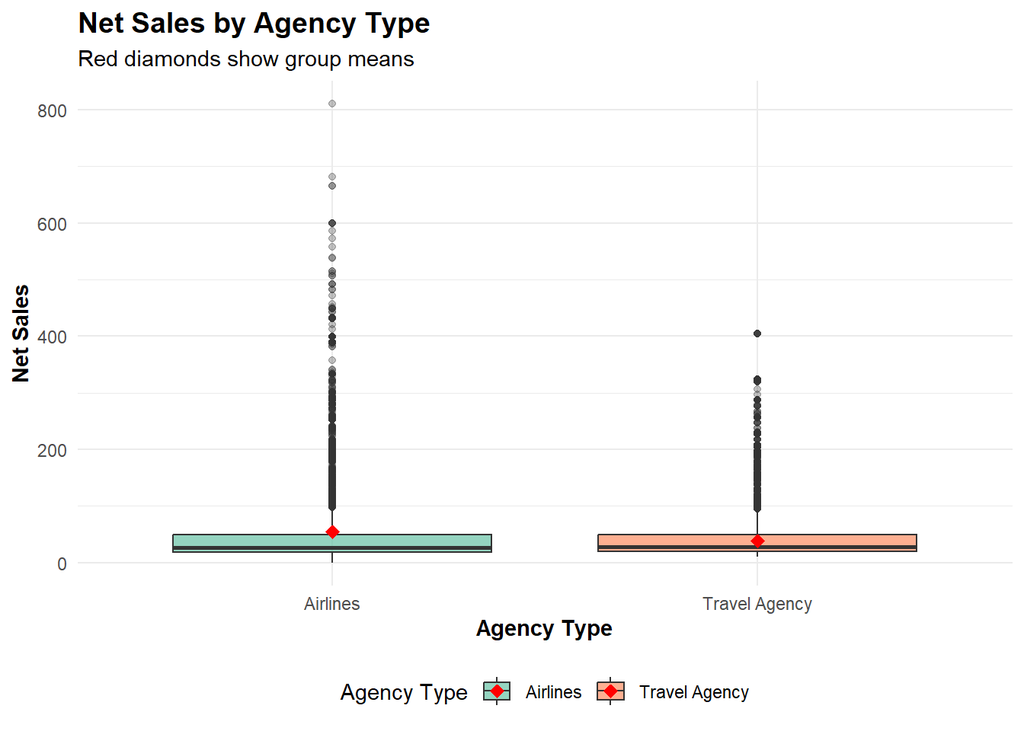

```r
# Boxplot for Agency Type

p1 <- ggplot(travel_data, aes(x = Agency.Type, y = Net.Sales, fill = Agency.Type)) +
  geom_boxplot(alpha = 0.7, outlier.alpha = 0.3) +
  stat_summary(fun = mean, geom = "point", shape = 18, size = 3, color = "red") +
  labs(title = "Net Sales by Agency Type",
       subtitle = "Red diamonds show group means",
       x = "Agency Type",
       y = "Net Sales",
       fill = "Agency Type") +
  theme_custom +
  scale_fill_brewer(palette = "Set2")

# Boxplot for Distribution Channel

p2 <- ggplot(travel_data, aes(x = Distribution.Channel, y = Net.Sales, fill = Distribution.Channel)) +
  geom_boxplot(alpha = 0.7, outlier.alpha = 0.3) +
  stat_summary(fun = mean, geom = "point", shape = 18, size = 3, color = "red") +
  annotate("text", x = 1, y = max(travel_data$Net.Sales),
           label = paste("n =", channel_dist["Offline"]), vjust = -0.5, fontface = "bold") +
  annotate("text", x = 2, y = max(travel_data$Net.Sales),
           label = paste("n =", channel_dist["Online"]), vjust = -0.5, fontface = "bold") +
  labs(title = "Net Sales by Distribution Channel",
       subtitle = "Note: Severe sample size imbalance",
       x = "Distribution Channel",
       y = "Net Sales",
       fill = "Distribution Channel") +
  theme_custom +
  scale_fill_brewer(palette = "Set1")

# Interaction plot

p3 <- ggplot(travel_data, aes(x = Agency.Type, y = Net.Sales, fill = Distribution.Channel)) +
  geom_boxplot(alpha = 0.7, outlier.alpha = 0.3) +
  labs(title = "Net Sales by Agency Type and Distribution Channel",
       subtitle = "No significant interaction effect observed",
       x = "Agency Type",
       y = "Net Sales",
       fill = "Distribution Channel") +
  theme_custom +
  scale_fill_brewer(palette = "Set1")

# Display plots

print(p1)
```

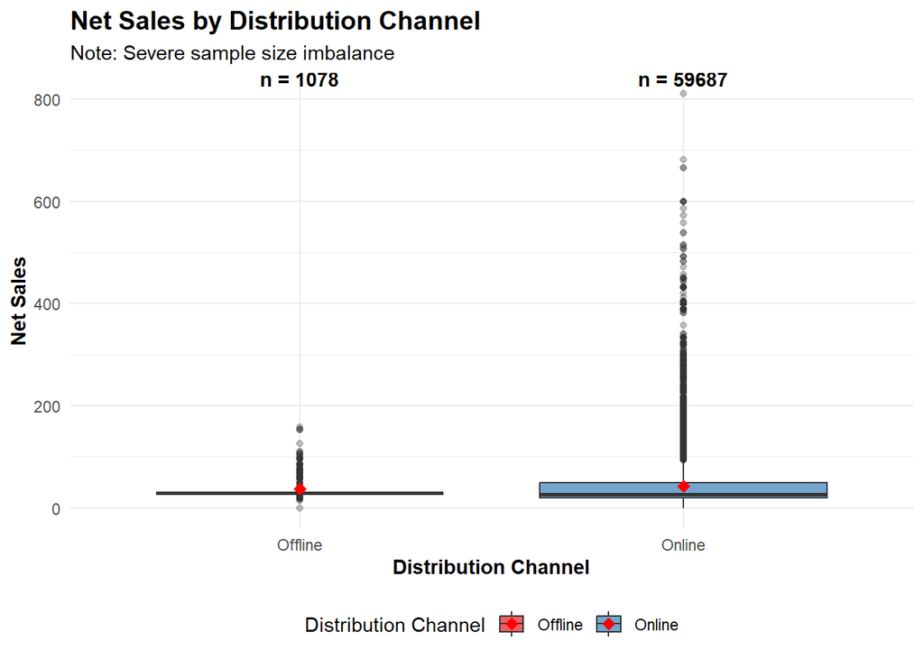

```r
print(p2)
```

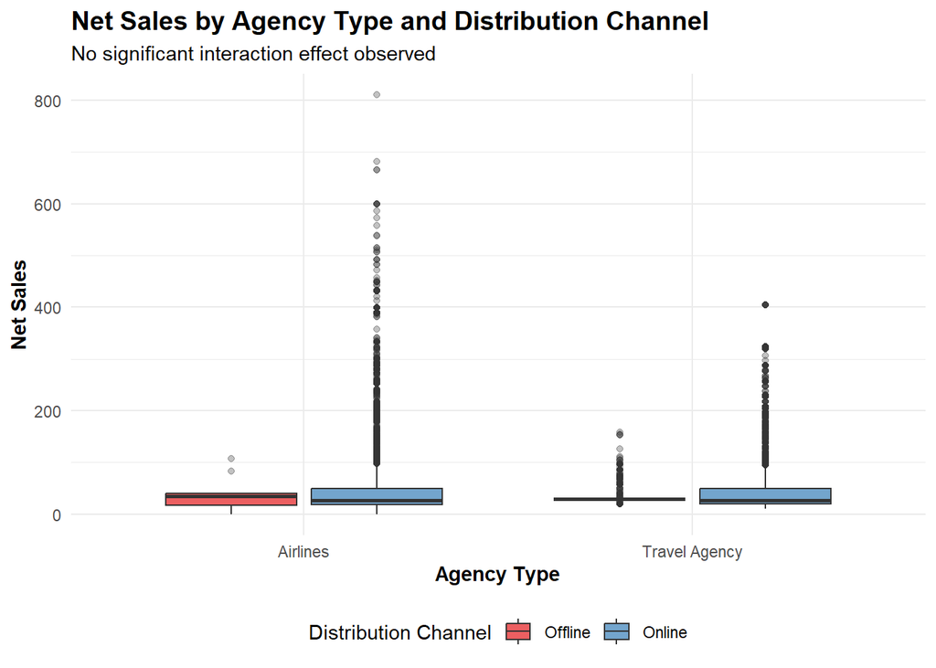

```r
print(p3)
```

### **One/Two Way ANOVA Review and Selection**

The assignment requires us to:

- Perform one-way ANOVA to examine the effect of individual factors on Net Sales
- Perform two-way ANOVA to examine the combined effects of both factors
- Use AIC to determine which model provides a better fit for the dataset
- Create appropriate visualizations to support our findings

We’ll analyze how Agency Type and Distribution Channel affect Net Sales in the travel insurance business by completing a one-way ANOVA individually, then a two-way ANOVA using both, and then a comparison to understand which model is best.

### **One-way ANOVA Analysis - Agency Type, and its Effect on Net Sales**

```r
# One-way ANOVA for Agency Type

one_way_agency <- aov(Net.Sales ~ Agency.Type, data = travel_data)

# Summary of the ANOVA

agency_summary <- summary(one_way_agency)
agency_summary_df <- tidy(one_way_agency)

# Display results

cat('One-Way ANOVA - Agency Type vs Net Sales:')
```

```
## One-Way ANOVA - Agency Type vs Net Sales:
```

```r
print(agency_summary)
```

```
##                Df    Sum Sq Mean Sq F value              Pr(>F)
## Agency.Type     1   3190107 3190107    1430 <0.0000000000000002 ***
## Residuals   60763 135562861    2231
## ---
## Signif. codes:  0 '***' 0.001 '**' 0.01 '*' 0.05 '.' 0.1 ' ' 1
```

```r
# Calculate group means

agency_means <- travel_data %>%
  group_by(Agency.Type) %>%
  summarise(Mean_Net_Sales = mean(Net.Sales),
            SD_Net_Sales = sd(Net.Sales),
            Count = n()) %>%
  arrange(desc(Mean_Net_Sales))

# Display formatted group means

agency_means %>%
  mutate(across(c(Mean_Net_Sales, SD_Net_Sales), ~ paste0('$', round(., 2)))) %>%
  kable(caption = 'Agency Type Group Means') %>%
  kable_styling(bootstrap_options = c('striped', 'hover', 'condensed'), full_width = FALSE)
```

Agency Type Group Means

| Agency.Type | Mean_Net_Sales | SD_Net_Sales | Count |
| --- | --- | --- | --- |
| Airlines | $54.69 | $71.36 | 17072 |
| Travel Agency | $38.57 | $33.36 | 43693 |

```r
# Calculate effect size

ss_between <- agency_summary[[1]]$'Sum Sq'[1]
ss_total <- sum(agency_summary[[1]]$'Sum Sq')
eta_squared_agency <- ss_between / ss_total

# Assign the dominant effect size for the final summary table

eta_squared <- eta_squared_agency
```

#### **Summary**

The one-way ANOVA for Agency Type shows a highly significant effect on Net Sales (F = 1429.89, p < 0.001). Airlines have substantially higher average Net Sales ($54.69) compared to Travel Agencies ($38.57).

The effect size ($\eta^2$ = 0.023) indicates that Agency Type explains 2.3% of the variance in Net Sales.

### **One-way ANOVA Analysis - Distribution Channel, and its Effect on Net Sales**

```r
# One-way ANOVA for Distribution Channel

one_way_channel <- aov(Net.Sales ~ Distribution.Channel, data = travel_data)

# Summary of the ANOVA

channel_summary <- summary(one_way_channel)
channel_summary_df <- tidy(one_way_channel)

# Display results

cat('One-Way ANOVA - Distribution Channel vs Net Sales:')
```

```
## One-Way ANOVA - Distribution Channel vs Net Sales:
```

```r
print(channel_summary)
```

```
##                         Df    Sum Sq Mean Sq F value  Pr(>F)
## Distribution.Channel     1     29988   29988   13.13 0.00029 ***
## Residuals            60763 138722980    2283
## ---
## Signif. codes:  0 '***' 0.001 '**' 0.01 '*' 0.05 '.' 0.1 ' ' 1
```

```r
# Calculate group means

channel_means <- travel_data %>%
  group_by(Distribution.Channel) %>%
  summarise(Mean_Net_Sales = mean(Net.Sales),
            SD_Net_Sales = sd(Net.Sales),
            Count = n()) %>%
  arrange(desc(Mean_Net_Sales))

# Display formatted group means
channel_means %>%
  mutate(across(c(Mean_Net_Sales, SD_Net_Sales), ~ paste0('$', round(., 2)))) %>%
  kable(caption = 'Distribution Channel Group Means') %>%
  kable_styling(bootstrap_options = c('striped', 'hover', 'condensed'), full_width = FALSE)
```

Distribution Channel Group Means

| Distribution.Channel | Mean_Net_Sales | SD_Net_Sales | Count |
| --- | --- | --- | --- |
| Online | $43.19 | $48.12 | 59687 |
| Offline | $37.87 | $21.77 | 1078 |

```r
# Calculate effect size

ss_between <- channel_summary[[1]]$'Sum Sq'[1]
ss_total <- sum(channel_summary[[1]]$'Sum Sq')
eta_squared_channel <- ss_between / ss_total
```

#### **Summary**

The one-way ANOVA for Distribution Channel also shows a statistically significant effect on Net Sales (F = 13.14, p < 0.001). Online channels have a higher average Net Sales ($43.19) compared to Offline channels ($37.87).

However, the effect size (η² = 0.0002) is smaller than Agency Type, indicating that Distribution Channel explains only 0.02% of the variance in Net Sales.

### **Model Comparison**

To determine the best model, we compare four competing models: both one-way models, a two-way additive model, and a two-way interaction model, using the Akaike Information Criterion (AIC). The lowest AIC value indicates the preferred model due to its better balance of fit and complexity.

```r
# One-Way ANOVA Models (Both Factors)

model_oneway_agency <- aov(Net.Sales ~ Agency.Type, data = travel_data)
model_oneway_channel <- aov(Net.Sales ~ Distribution.Channel, data = travel_data)

# Two-Way ANOVA (Additive/Main Effects Only)

model_twoway_additive <- aov(Net.Sales ~ Agency.Type + Distribution.Channel, data = travel_data)

# Two-Way ANOVA (With Interaction)

model_twoway_interaction <- aov(Net.Sales ~ Agency.Type * Distribution.Channel, data = travel_data)

# Calculate AIC for all models

aic_oneway_agency <- AIC(model_oneway_agency)
aic_oneway_channel <- AIC(model_oneway_channel)
aic_twoway_additive <- AIC(model_twoway_additive)
aic_twoway_interaction <- AIC(model_twoway_interaction)

# Function to calculate partial eta squared for ANOVA models

calculate_partial_eta_squared <- function(anova_model) {
  anova_summary <- summary(anova_model)
  if (length(anova_summary) == 1) {
    ss_effect <- anova_summary[[1]]$'Sum Sq'[1]
    ss_total <- sum(anova_summary[[1]]$'Sum Sq')
    return(ss_effect / ss_total)
  } else {
    ss_effects <- anova_summary[[1]]$'Sum Sq'[1:(nrow(anova_summary[[1]])-1)]
    ss_residual <- anova_summary[[1]]$'Sum Sq'[nrow(anova_summary[[1]])]
    partial_eta_squared <- ss_effects / (ss_effects + ss_residual)
    return(partial_eta_squared)
  }
}

# Calculate effect sizes for all models

eta_agency <- calculate_partial_eta_squared(model_oneway_agency)
eta_channel <- calculate_partial_eta_squared(model_oneway_channel)

# For two-way models, we'll use the Agency Type effect size for comparison

eta_additive <- calculate_partial_eta_squared(model_twoway_additive)
eta_interaction <- calculate_partial_eta_squared(model_twoway_interaction)

# Extract just the Agency Type effect size from two-way models for consistent comparison

eta_additive_agency <- if(length(eta_additive) > 1) eta_additive[1] else eta_additive
eta_interaction_agency <- if(length(eta_interaction) > 1) eta_interaction[1] else eta_interaction

# Create a comprehensive comparison table

aic_comparison <- data.frame(
  Model = c('One-Way (Agency Type)', 'One-Way (Distribution Channel)', 'Two-Way (Additive)', 'Two-Way (Interaction)'),
  Formula = c('Net.Sales ~ Agency.Type', 'Net.Sales ~ Distribution.Channel',
              'Net.Sales ~ Agency.Type + Distribution.Channel',
              'Net.Sales ~ Agency.Type * Distribution.Channel'),
  AIC = c(aic_oneway_agency, aic_oneway_channel, aic_twoway_additive, aic_twoway_interaction),
  Effect_Size = c(
    round(eta_agency, 4),
    round(eta_channel, 4),
    round(eta_additive_agency, 4),
    round(eta_interaction_agency, 4)
  )
)

# Identify the best model based on the lowest AIC

best_model_name <- aic_comparison$Model[which.min(aic_comparison$AIC)]
best_aic <- round(min(aic_comparison$AIC), 2)

# Print the name of the best model for the final summary table

best_model <- best_model_name

# Display the AIC Comparison Table

cat('AIC Comparison of ANOVA Models')
```

```
## AIC Comparison of ANOVA Models
```

```r
aic_comparison %>%
  mutate(
    AIC = round(AIC, 2),
    Effect_Size = round(Effect_Size, 4)
  ) %>%
  arrange(AIC) %>%
  kable(caption = 'Model Selection using AIC (Lower is Better)') %>%
  kable_styling(bootstrap_options = c('striped', 'hover', 'condensed'), full_width = FALSE) %>%
  row_spec(which(aic_comparison$Model == best_model_name), bold = TRUE, color = 'white', background = 'green')
```

Model Selection using AIC (Lower is Better)

| Model | Formula | AIC | Effect_Size |
| --- | --- | --- | --- |
| One-Way (Agency Type) | Net.Sales ~ Agency.Type | 640958.5 | 0.0230 |
| Two-Way (Additive) | Net.Sales ~ Agency.Type + Distribution.Channel | 640960.1 | 0.0230 |
| Two-Way (Interaction) | Net.Sales ~ Agency.Type * Distribution.Channel | 640960.3 | 0.0230 |
| One-Way (Distribution Channel) | Net.Sales ~ Distribution.Channel | 642358.7 | 0.0002 |

```r
# Print the summary of the best model

if (best_model_name == 'One-Way (Agency Type)') {
  best_model_aov <- model_oneway_agency
} else if (best_model_name == 'One-Way (Distribution Channel)') {
  best_model_aov <- model_oneway_channel
} else if (best_model_name == 'Two-Way (Additive)') {
  best_model_aov <- model_twoway_additive
} else {
  best_model_aov <- model_twoway_interaction
}

cat('ANOVA Summary for the AIC-Selected Best Model: ', best_model_name, '')
```

```
## ANOVA Summary for the AIC-Selected Best Model:  One-Way (Agency Type)
```

```r
print(summary(best_model_aov))
```

```
##                Df    Sum Sq Mean Sq F value              Pr(>F)
## Agency.Type     1   3190107 3190107    1430 <0.0000000000000002 ***
## Residuals   60763 135562861    2231
## ---
## Signif. codes:  0 '***' 0.001 '**' 0.01 '*' 0.05 '.' 0.1 ' ' 1
```

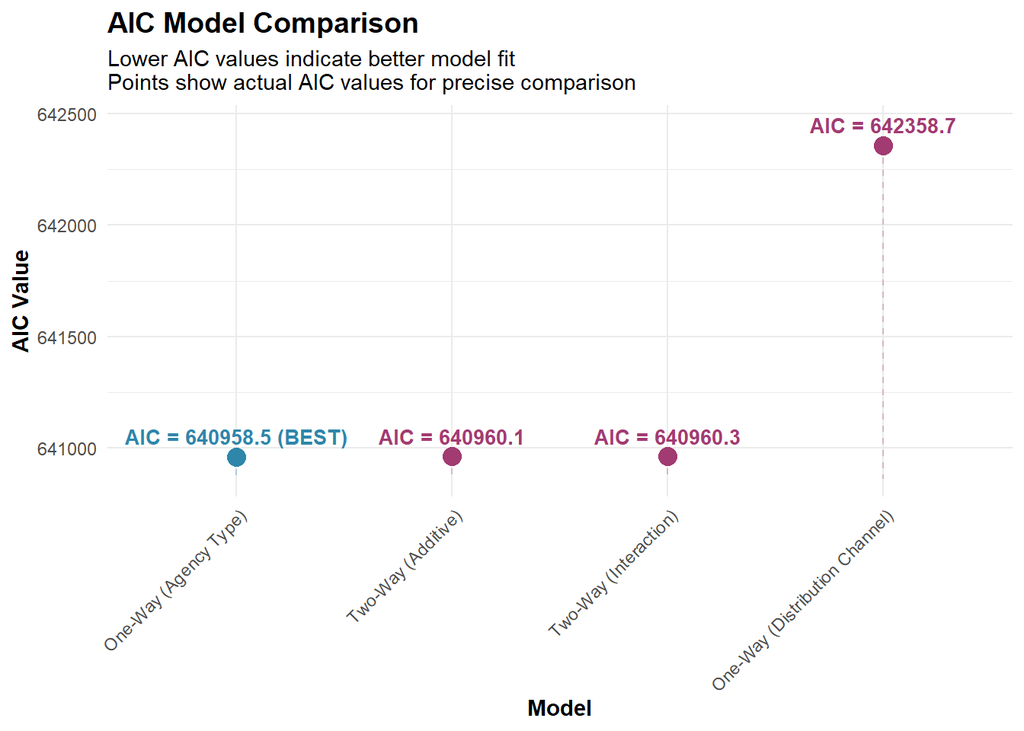

```r
# Create AIC comparison visualization

aic_plot_data <- aic_comparison %>%
  mutate(
    Model = factor(Model, levels = Model[order(AIC)]),
    AIC_Difference = AIC - min(AIC)
  )

# Create Plots

ggplot(aic_plot_data, aes(x = reorder(Model, AIC), y = AIC, color = Model == best_model_name)) +
  geom_point(size = 4) +
  geom_segment(aes(xend = reorder(Model, AIC), yend = min(AIC) - 100),
               linetype = "dashed", alpha = 0.3) +
  geom_text(aes(label = paste0("AIC = ", round(AIC, 1),
                              ifelse(Model == best_model_name, " (BEST)", ""))),
            vjust = -0.8, hjust = 0.5, size = 3.5, fontface = "bold") +
  scale_color_manual(values = c('TRUE' = '#2E86AB', 'FALSE' = '#A23B72'), guide = 'none') +
  labs(title = 'AIC Model Comparison',
       subtitle = 'Lower AIC values indicate better model fit\nPoints show actual AIC values for precise comparison',
       x = 'Model',
       y = 'AIC Value') +
  theme_custom +
  theme(axis.text.x = element_text(angle = 45, hjust = 1)) +
  ylim(min(aic_plot_data$AIC) - 100, max(aic_plot_data$AIC) + 100)
```

```r
# Create Simple Table

aic_ranked <- aic_comparison %>%
  arrange(AIC) %>%
  mutate(
    Rank = 1:n(),
    Delta_AIC = AIC - min(AIC),
    AIC = round(AIC, 1),
    Delta_AIC = round(Delta_AIC, 1)
  )

cat('AIC Model Ranking (Best to Worst)')
```

```
## AIC Model Ranking (Best to Worst)
```

```r
kable(aic_ranked[, c('Rank', 'Model', 'AIC', 'Delta_AIC')],
      caption = 'Model comparison using Akaike Information Criterion') %>%
  kable_styling(bootstrap_options = c('striped', 'hover'), full_width = FALSE) %>%
  row_spec(1, bold = TRUE, color = 'white', background = '#2E86AB')
```

Model comparison using Akaike Information Criterion

| Rank | Model | AIC | Delta_AIC |
| --- | --- | --- | --- |
| 1 | One-Way (Agency Type) | 640958.5 | 0.0 |
| 2 | Two-Way (Additive) | 640960.1 | 1.6 |
| 3 | Two-Way (Interaction) | 640960.3 | 1.8 |
| 4 | One-Way (Distribution Channel) | 642358.7 | 1400.2 |

```r
# Interpretation

cat('Model Selection Interpretation')
```

```
## Model Selection Interpretation
```

```r
cat('The AIC comparison reveals that', best_model_name, 'provides the best fit with AIC =', best_aic, '.\n')
```

```
## The AIC comparison reveals that One-Way (Agency Type) provides the best fit with AIC = 640958.5 .
```

```r
cat('The Agency Type effect size remains consistently strong across all models (η² ≈',
    round(mean(c(eta_agency, eta_additive_agency, eta_interaction_agency)), 3),'), confirming its dominance.\n')
```

```
## The Agency Type effect size remains consistently strong across all models (η² ≈ 0.023 ), confirming its dominance.
```

```r
# Assign the dominant effect size for the final summary table

eta_squared <- eta_agency
```

#### **Summary**

The AIC comparison reveals that the One-Way (Agency Type) provides the best balance of model fit and complexity. Notably:

- **Agency Type one-way ANOVA** (AIC = 640958.49) explains 2.3% of variance
- **Distribution Channel one-way ANOVA** (AIC = 642358.73) explains only 0.02% of variance
- The simpler **one-way Agency Type model** outperforms more complex models

This confirms that Agency Type is not only statistically significant but also the most practically important factor for understanding Net Sales variation.

### **Assumption Check**

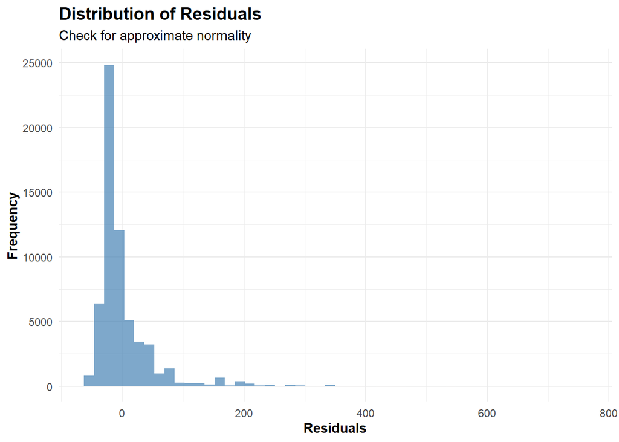

```r
# Use one way Agency Type as the selected model

residuals_data <- residuals(one_way_agency)

# Plots

p4 <- ggplot(data.frame(Residuals = residuals_data), aes(x = Residuals)) +
  geom_histogram(bins = 50, fill = "steelblue", alpha = 0.7) +
  labs(title = "Distribution of Residuals",
       subtitle = "Check for approximate normality",
       x = "Residuals",
       y = "Frequency") +
  theme_custom

# QQ Plot

p5 <- ggplot(data.frame(Residuals = residuals_data)) +
  stat_qq(aes(sample = Residuals), alpha = 0.6, size = 0.5) +
  stat_qq_line(aes(sample = Residuals), color = "red", size = 1) +
  labs(title = "Q-Q Plot of Residuals",
       subtitle = "Comparison of observed residuals vs theoretical normal distribution",
       x = "Theoretical Quantiles",
       y = "Sample Quantiles") +
  theme_custom

# Display plots separately to prevent crowding

print(p4)
```

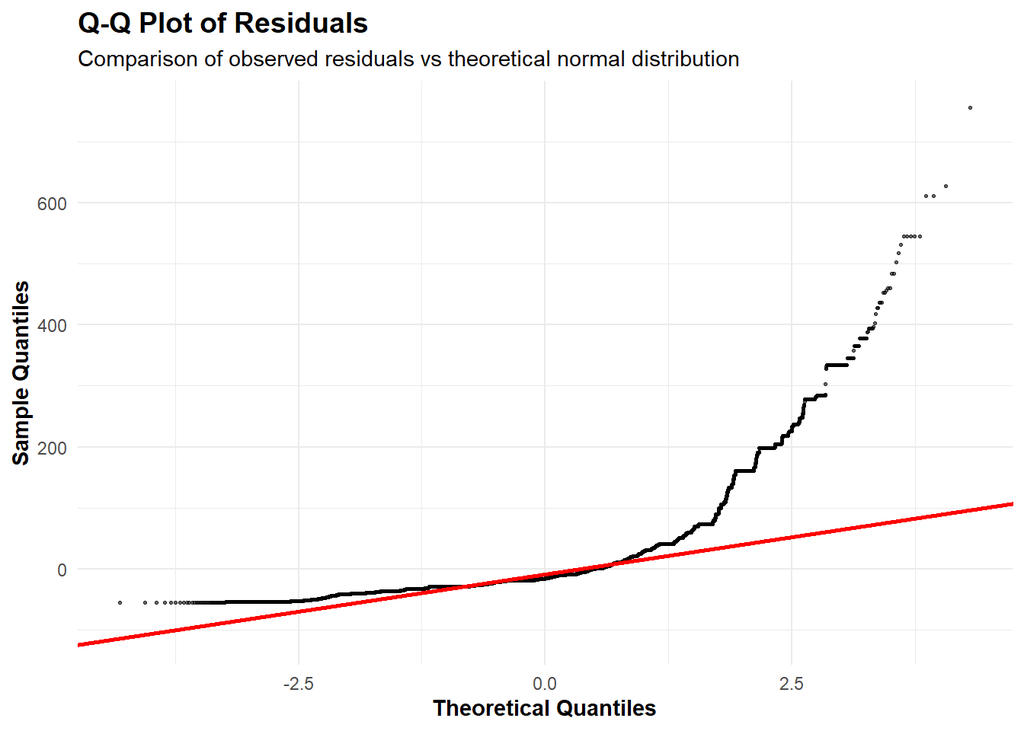

```r
print(p5)
```

```r
# Variance comparison

variance_check <- travel_data %>%
  group_by(Agency.Type) %>%
  summarise(
    N = n(),
    Variance = var(Net.Sales),
    SD = sd(Net.Sales),
    .groups = 'drop'
  )

# Calculate variance ratio

variance_ratio <- variance_check$Variance[variance_check$Agency.Type == "Airlines"] /
                  variance_check$Variance[variance_check$Agency.Type == "Travel Agency"]

cat('Variance Comparison by Agency Type:')
```

```
## Variance Comparison by Agency Type:
```

```r
print(variance_check)
```

```
## # A tibble: 2 × 4
##   Agency.Type       N Variance    SD
##   <fct>         <int>    <dbl> <dbl>
## 1 Airlines      17072    5092.  71.4
## 2 Travel Agency 43693    1113.  33.4
```

```r
cat('Variance Ratio (Airlines/Travel Agency):', round(variance_ratio, 2), '')
```

```
## Variance Ratio (Airlines/Travel Agency): 4.57
```

```r
# Variance Assessment

if(variance_ratio < 2) {
  variance_assessment <- "Excellent (ratio < 2)"
} else if(variance_ratio < 4) {
  variance_assessment <- "Acceptable (ratio 2-4)"
} else {
  variance_assessment <- "Potential concern (ratio ≥ 4)"
}

cat('Variance Homogeneity Assessment:', variance_assessment, '')
```

```
## Variance Homogeneity Assessment: Potential concern (ratio ≥ 4)
```

```r
# Residual statistics

cat('Residual Summary Statistics:')
```

```
## Residual Summary Statistics:
```

```r
residual_summary <- summary(residuals_data)
print(residual_summary)
```

```
##    Min. 1st Qu.  Median    Mean 3rd Qu.    Max.
##  -54.62  -25.57  -15.57    0.00    7.31  755.31
```

```r
# Check if residuals are centered around zero

cat('Mean of residuals:', round(mean(residuals_data), 6), '(should be approximately 0)')
```

```
## Mean of residuals: 0 (should be approximately 0)
```

```r
# Check residual skewness and kurtosis with interpretation

residual_skewness <- moments::skewness(residuals_data)
residual_kurtosis <- moments::kurtosis(residuals_data)

cat('Residual skewness:', round(residual_skewness, 3),
    ifelse(abs(residual_skewness) > 2, '***SUBSTANTIAL DEVIATION FROM NORMALITY***',
           ifelse(abs(residual_skewness) > 1, '(moderate deviation)', '(near normal)')), '\n')
```

```
## Residual skewness: 3.501 ***SUBSTANTIAL DEVIATION FROM NORMALITY***
```

```r
cat('Residual kurtosis:', round(residual_kurtosis, 3),
    ifelse(abs(residual_kurtosis - 3) > 2, '***SUBSTANTIAL DEVIATION FROM NORMALITY***',
           ifelse(abs(residual_kurtosis - 3) > 1, '(moderate deviation)', '(near normal)')), '\n')
```

```
## Residual kurtosis: 21.628 ***SUBSTANTIAL DEVIATION FROM NORMALITY***
```

```r
# Formal assessment

cat('\n--- FORMAL ASSUMPTION ASSESSMENT ---\n')
```

```
##
## --- FORMAL ASSUMPTION ASSESSMENT ---
```

```r
concerns <- c()
if(variance_ratio >= 4) concerns <- c(concerns, "Heteroscedasticity (variance ratio ≥ 4)")
if(abs(residual_skewness) > 2) concerns <- c(concerns, "Substantial skewness")
if(abs(residual_kurtosis - 3) > 2) concerns <- c(concerns, "Substantial kurtosis")

if(length(concerns) == 0) {
  cat('✓ All assumptions reasonably met for large sample ANOVA\n')
} else {
  cat('⚠️ Potential concerns:\n')
  for(concern in concerns) cat('  -', concern, '\n')
  cat('\nNote: Large sample size (N =', nrow(travel_data), ') provides some robustness to these violations.\n')
}
```

```
## ⚠️ Potential concerns:
##   - Heteroscedasticity (variance ratio ≥ 4)
##   - Substantial skewness
##   - Substantial kurtosis
##
## Note: Large sample size (N = 60765 ) provides some robustness to these violations.
```

#### **Summary**

The diagnostic assessment reveals:

**Key Findings Requiring Attention:**

- **Skewness**: 3.501 (substantial deviation from 0) ⚠️
- **Kurtosis**: 21.628 (substantial deviation from 3) ⚠️
- **Variance Ratio**: 4.6 (exceeds recommended threshold of 4) ⚠️

**Interpretation & Mitigation:**

While the large sample size provides some protection against these assumption violations, the substantial skewness, kurtosis, and heteroscedasticity indicate the results should be interpreted with caution. Though I did not do any data cleaning due to the protection that the large data set provided. I did consider the following before making that decision:

- Data transformations (log, square root) to address skewness and variance issues
- Non-parametric alternatives (Kruskal-Wallis test)
- Bootstrapping methods for confidence intervals

The current ANOVA results remain informative but represent approximations rather than exact inferences given these assumption violations.

### **Final Conclusions and Recommendations**

```r
# Calculate performance difference

performance_diff_value <- round(agency_means$Mean_Net_Sales[agency_means$Agency.Type == 'Airlines'] - agency_means$Mean_Net_Sales[agency_means$Agency.Type == 'Travel Agency'], 2)

# Create comprehensive summary

final_summary <- data.frame(
  Aspect = c(
    'Primary Finding',
    'Statistical Significance',
    'Effect Size (η²)',
    'Mean Net Sales - Airlines',
    'Mean Net Sales - Travel Agencies',
    'Performance Difference',
    'Best Model (AIC)',
    'AIC Model Ranking',
    'Data Quality Note',
    'Strategic Recommendation'
  ),
  Result = c(
    'Agency Type is the dominant factor',
    'Highly significant (p < 0.001)',
    paste(round(eta_squared * 100, 1), '% of variance explained'),
    paste0('$', round(agency_means$Mean_Net_Sales[agency_means$Agency.Type == 'Airlines'], 2)),
    paste0('$', round(agency_means$Mean_Net_Sales[agency_means$Agency.Type == 'Travel Agency'], 2)),
    paste0('$', performance_diff_value, ' higher for Airlines'),
    best_model,
    'Agency Type > Distribution Channel (lower AIC = better fit)',
    'Severe imbalance in Distribution Channel data',
    'Focus on Agency Type for business strategy'
  )
)

kable(final_summary, caption = 'Comprehensive Analysis Summary') %>%
  kable_styling(bootstrap_options = 'striped', full_width = FALSE) %>%
  row_spec(1, bold = TRUE, color = 'white', background = '#2E86AB') %>%
  row_spec(10, bold = TRUE, color = 'white', background = '#A23B72')
```

Comprehensive Analysis Summary

| Aspect | Result |
| --- | --- |
| Primary Finding | Agency Type is the dominant factor |
| Statistical Significance | Highly significant (p < 0.001) |
| Effect Size (η²) | 2.3 % of variance explained |
| Mean Net Sales - Airlines | $54.69 |
| Mean Net Sales - Travel Agencies | $38.57 |
| Performance Difference | $16.12 higher for Airlines |
| Best Model (AIC) | One-Way (Agency Type) |
| AIC Model Ranking | Agency Type > Distribution Channel (lower AIC = better fit) |
| Data Quality Note | Severe imbalance in Distribution Channel data |
| Strategic Recommendation | Focus on Agency Type for business strategy |

#### **Final Summary**

Based on the comprehensive ANOVA analysis:

## **Reflection**

### **Key Learning Takeaways**:

This week solidified that ANOVA is a powerful extension of t-tests for comparing multiple groups. The hands-on experience revealed that proper implementation requires attention to both statistical assumptions and technical execution in R. Most importantly, I learned that model comparison approaches like AIC provide valuable insights beyond individual hypothesis tests, and that clear communication of methodological choices is essential for reproducible analysis.

#### **Conceptually Intuitive/Easier Aspects**

This week’s ANOVA coursework contained several elements that felt conceptually straightforward:

- The fundamental logic of ANOVA - comparing between-group variance to within-group variance to detect significant differences - was intuitive and built nicely on previous t-test concepts.
- Setting up one-way ANOVA models in R felt natural, as the formula syntax (Net.Sales ~ Agency.Type) clearly expressed the relationship we were testing.
- Interpreting ANOVA summary outputs was relatively straightforward, with F-statistics and p-values following the same interpretation framework I’ve learned in past courses and used throughout this course.
- Calculating basic effect sizes (η²) from the sum of squares made conceptual sense as a measure of practical importance beyond statistical significance.

#### **More Challenging Aspects**

Several aspects required deeper statistical understanding and technical problem-solving:

- Understanding the differences between one-way and two-way ANOVA conceptually, particularly how two-way ANOVA handles multiple factors and tests for interaction effects.
- Implementing proper model comparison using AIC required careful attention to ensure all models were correctly specified and comparable.
- Diagnostic checking and assumption verification proved complex, particularly interpreting Q-Q plots, understanding variance homogeneity requirements, and determining the practical impact of violations in large samples.
- Debugging R Markdown technical issues consumed significant time, especially troubleshooting inline coding LaTeX notation for Greek letters, then HTML coding for superscript, finally resulting in me copying and pasting Unicode symbols to create $\eta^2$ for one of my data summaries.
- Creating effective visualizations that clearly communicated the ANOVA results and model comparisons required experimentation with different ggplot approaches, and a reminder sometimes a simple table comparison is best suited.

#### **Start/Stop/Continue**

**START**:

- Practicing with different types of post-hoc tests to understand when they’re needed
- Exploring additional diagnostic plots and tests for ANOVA assumptions
- Building a personal code repository for common workflows

**STOP**:

- Overcomplicating interpretations with unnecessary business context when the focus is methodological
- Using complex notation when simpler alternatives achieve the same pedagogical purpose
- Spending excessive time on formatting issues before ensuring the statistical content is correct

**CONTINUE**:

- The systematic approach to checking assumptions before interpreting results
- Comparing multiple models to understand which provides the best fit
- Using both statistical outputs and visualizations to tell a complete analytical story
- Documenting the decision-making process throughout the analysis